# Markowitz - Seleção de carteiras

Alícia, Neuremberg e Sarah

8 de janeiro de 2020

### Definição de risco e retorno

Considere uma série de preços de uma ação em que cada preço de refere a uma observação em um determinado período de tempo:

$$P = \{p_1, p_2, ..., p_n\}$$

O *retorno efetivo* do ativo no período $t=2$ é dado por $R_2 = p_2 - p_1$. A ideia é que se um agente comprasse o ativo no período 1 ao preço $p_1$ e o vendesse no período 2 ao $p_2$, ele teria o ganho de $R_2$ unidades monetárias. Entretanto, para que essa medida de ganho seja comparável entre ativos diferentes se usa frequentemente o retorno percentual como medida de retorno, isto é:

$$R_2 = \frac{p_2 - p_1}{p_1}$$

Os valores de retornos efetivos já observados são chamados também de retornos históricos.

Uma medida mais interessante para o investidor é qual será o retorno do ativo no futuro. Este tipo de retorno é chamado de *retorno esperado*. Enquanto o retorno efetivo diz respeito ao que ocorreu de fato, o retorno esperado desrespeita ao que ocorrerá no futuro, portanto, uma expectativa. Matematicamente, pode-se definir o retorno esperado como:

$$\mu = E(R) = \sum_{i=1}^n{p_iR_i}$$
Em outros termos, o retorno esperado é o somatório dos retornos do ativo ponderado pelo pelas respectivas probabilidades de ocorrência. Assim, para calcular o retorno esperado pela definição deve-se saber todos os retornos que o ativo pode ter e quais as probabilidades associados a eles. Isso significa dizer que se conhece todos os cenários que podem ocorrer, suas probabilidades e retornos associados a eles.

Na maioria dos casos não se tem este tipo de conhecimento sobre os retornos de determinado ativo. Nesse caso, os retornos históricos podem serem usados para estimar o retorno esperado, mas não há nenhuma garantia de que o retorno futuro será o mesmo que o já observado no passado. Disto isto, neste *post* o retorno esperado de um ativo será estimado como sendo a média aritmética do retornos históricos. Essa abordagem será adotada em razão da sua simplicidade.

Além da medida de retorno, outra medida de grande importância para os investidores é o risco associado aos ativos. Tal métrica mede o quanto em média o valor do retorno efetivo irá divergir do retorno esperado. Isso significa que ativos com risco alto têm retornos efetivos que divergem bastante do retorno esperado, ao mesmo tempo que o ativos menos arriscados têm retornos efetivos que divergem pouco do retorno esperado.

O gráfico a seguir ilustra intuitivamente essa ideia. Considere dois ativos que têm o retorno esperado de 4%, entretanto o ativo *A* possui um risco menor que o ativo *B*:

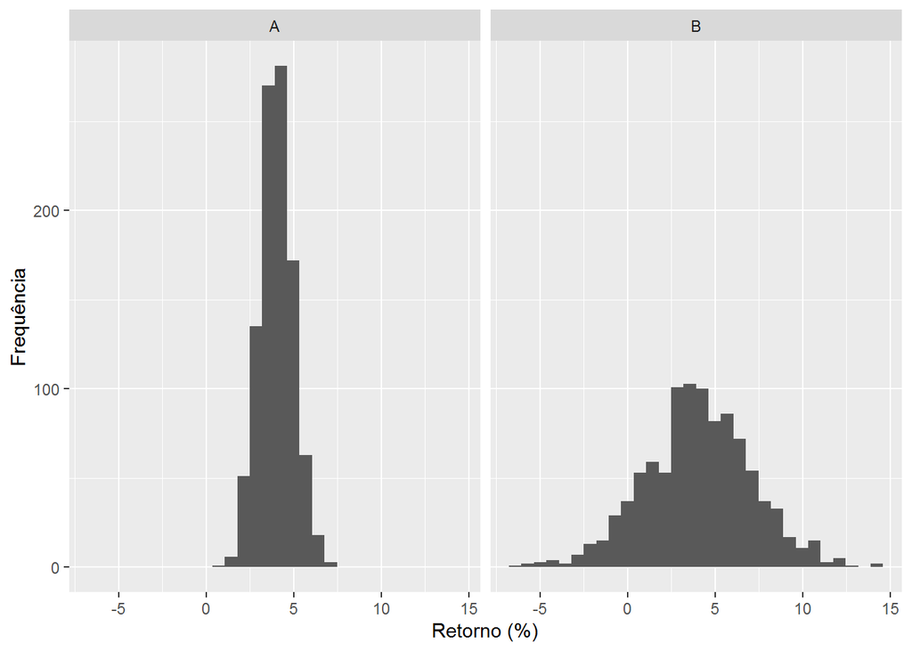

Como consequência os retornos efetivos do ativo *A* são bem mais concentrados, ou próximos, ao retorno esperado do ativo. Ao mesmo tempo que os retornos efetivos de ativo *B* são bem mais dispersos. Formalmente, o risco de um ativo é definido como o desvio padrão dos retornos efetivos em relação ao retorno esperado:

$$\sigma = (E[(R_i - \mu)^2])^{0,5}$$

O desvio padrão não é a única medida para avaliar risco. A semi-variância ou *downside risk* é outro exemplo de medida de risco. Ela formula a ideia de que a variância oriunda de retornos efetivos acima do retorno esperado não deveria ser computado como risco. Pois, quando o retorno efetivo for maior que o retorno esperado isso é um risco “bom”, porém, o risco é em geral associado ao custo de manter determinado ativo.

Nesse *post* será usado o desvio padrão como medida de risco. Além disso, cabe considerar que a discussão sobre a viabilidade de calcular o retorno a partir da definição se aplica também para o cálculo do risco. Dessa forma, será usado o desvio padrão histórico como estimador para o risco.

### Risco e retorno para carteiras

Até agora foi abordado o risco e retorno do ponto de vista de um ativo individual. Entretanto, seria interessante analisar vários ativos em conjunto. Essa é a ideia de carteira. De modo geral, uma carteira é um conjunto de ativos, a participação de cada ativo no valor total da carteira é chamado de peso do ativo na carteira. Assim, se um ativo alcança o valor $ 10 em uma carteira com o valor total de $ 100, então esse ativo tem peso de 10% na carteira.

Dito isso, o retorno esperado de uma carteira é dada por:

$$R_c = \sum_{i=1}^{n}w_i R_i$$

Em que $n$ é a quantidade de ativos que compõe a carteira, $w_i$ a participação de do ativo $i$ na carteira e $R_i$ o retorno esperado do ativo $i$. Usando a notação matricial podemos descrever essa relação como um produto interno entre dois vetores:

$$R_c = w'R$$
Sendo $w$ um vetor coluna com as participações dos ativos na carteira e $w'$ a sua transporta e $R$ outro vetor coluna que contém os retornos dos ativos da carteira:

$$w = \begin{bmatrix}
w_{1} \\
w_{2} \\
\vdots \\
w_{n}
\end{bmatrix},
w' = \begin{bmatrix}
w_1 & w_2 & \dots & w_n
\end{bmatrix},
R = \begin{bmatrix}
R_{1} \\
R_{2} \\
\vdots \\
R_{n}
\end{bmatrix}$$

De agora em diante, um vetor sempre será tratado como uma matriz com uma coluna.

Já o variância da carteira - quadrado do seu risco - é definida como:

$$Var(R_p) = w_iw_j\sum_{i}\sum_{j} cov(R_i,R_j)$$

Para o caso de uma carteira com dois ativo podemos reescrever a relação como:

$$\begin{equation}
\begin{split}
Var(R_p) & = w_1w_1cov(R_1, R_1) + w_1w_2cov(R_1, R_2) + w_2w_1cov(R_2, R_1) + w_2w_2cov(R_2, R_2) \\
Var(R_p) & = w_1^2\sigma_{11} + w_1w_2\sigma_{12} + w_2w_1\sigma_{21} + w_2^2\sigma_{22}
\end{split}
\end{equation}$$

Sendo $cov(R_i,R_i) = var(R_i) = \sigma_{ii} = \sigma_{i}^2$ e $cov(R_i, R_j) = cov(R_j, R_i)$ segue:

$$Var(R_p) = w_1^2\sigma_1^2 + 2w_1w_2\sigma_{12} + w_2^2\sigma_{2}^2$$

Diferente do caso do retorno, o risco de uma carteira não é igual à média ponderada dos riscos de cada ativo. A razão para isso é que em geral sempre há uma relação entre a evolução de um preço de ativo $A$ e um ativo $B$, por exemplo, há um relação entre a evolução dos preços das ações da Petrobras e da Vale dado que ambas exportam *commodities*. No caso da carteira com dois ativos, o relacionamentos entre os dois ativos é captado pela covariância entre eles, $\sigma_{12}$.

O risco de uma carteira com *n* ativos pode ser definido como:

$$Var(R_p) = w'\Omega w$$
Novamente $w$ é o vetor com a participação de cada ativo na carteira, já $\Omega$ é a matriz do covariância dos retornos dos ativos:

$$\Omega = \begin{bmatrix}
\sigma_{11} & \sigma_{12} & \dots & \sigma_{1n} \\
\sigma_{21} & \sigma_{22} & \dots & \sigma_{2n} \\
\vdots & \vdots & \ddots & \vdots \\
\sigma_{n1} & \sigma_{n2} & \dots & \sigma_{nn}
\end{bmatrix}$$

Assim, cada célula $\sigma_{ij}$ da matriz é a covariância entre os retornos do ativo $i$ e dos retornos do ativo $j$. Como $\sigma_{ij} = \sigma_{ji}$, $\Omega$ é uma matriz simétrica cuja diagonal é a variância dos ativos.

### Tipos de Risco

O risco, pode ser dividido em dois tipos: idiossincrático, também conhecido como risco não sistemático, e sistemático.

O risco idiossincrático está associado a variância específica do ativo mensurado, é uma característica única do ativo. No caso, por exemplo, de um seguro para casas, assaltos são riscos idiossincráticos, pois dependendo da vizinhança, segurança interna ou até mesmo da aparência, cada casa possui uma chance de ser assaltada ou não, e, não necessariamente, caso uma casa seja assaltada as outras serão também. Esse risco não será tão relevante para o modelo apresentado mais a frente, isso ficará mais claro a seguir.

Já o risco sistemático é aquele ao qual estão sujeitos todos os ativos negociados, isso pode incluir não só ativos que estão listados em bolsas, como também os negociados em mercados de balcão, moedas, etc. Voltando ao exemplo do seguro, o risco sistemático seria a chance de haver um desastre natural que atingisse todas as casas, independentemente de qualquer característica individual de cada casa.

### Diversificação

Para entender a diversificação é preciso que esteja clara a distinção entre os tipos de risco. O risco não sistemático então é aquele que afetará somente um ou alguns ativos. No caso das ações de uma empresa seu risco específico está relacionado às decisões de investimentos tomadas pelo gestor, investimentos com $VPL$ positivo impactam positivamente o valor de uma ação, porém a ocorrência de greves ou fraudes terá impacto negativo.

Já como risco sistemático podemos citar eventos macroeconômicos como a inflação que afeta oferta e demanda de todo um país, é em diferentes níveis para cada tipo de bem, serviço ou setor, mas de maneira geral toda a economia é afetada.

Dadas tais diferenças é possível perceber que em uma carteira com vários ativos, apesar de todos estarem sujeitos ao risco sistemático, cada um deles terá também seu risco específico e enquanto alguns sofrem valorização outros terão queda no preço, e assim é feita a compensação de ganhos e perdas, por isso é importante que uma carteira possua um bom número de ativos e que estes sejam escolhidos de maneira que os riscos não sistemáticos tenham pouca relação entre si.

Podemos voltar então ao exemplo de uma companhia de seguros para exemplificar como funciona a diversificação. Digamos que existem apenas dois riscos envolvendo as casas asseguradas de uma cidade: desastres naturais e roubos. Não é possível a seguradora evitar que ocorram desastres ou que as casas não sejam atingidas por eles, esse risco também pode ser maior ou menor dependendo da época do ano. Porém, os roubos não atingem todas as casas ao mesmo tempo e as ocorrências podem ser maiores a depender de bairro, aparência das casas, etc. Nesse caso, seria prudente que a seguradora tivesse imóveis assegurados dos mais diferentes tipos e também em lugares diferentes. O risco de desastres não é eliminado por diversificação, porém o risco de perdas devido a assaltos diminui quanto maior for a diversificação.

A correlação é a medida da estatística utilizada para medir se dois ativos possuem flutuações muito ou pouco parecidas, é, no cálculo, o que fará o risco aumentar ou diminuir ao montar uma carteira de investimentos. Pode variar de -1, que é quando os ativos possuem correlação perfeitamente negativa, a 1, ativos com correlação perfeitamente positiva. Quanto mais próxima de 1, maior o risco da carteira, pois neste caso, os ativos se comportam de maneira muito parecida, e quanto mais próxima de -1, menor o desvio padrão da carteira.

### Escolha de uma carteira

Não existe uma carteira que seja a melhor para todos investidores. Isso ocorre por que investidor têm preferências diferentes de combinação de risco e retorno, e tais preferências variam de acordo com fatores como idade, renda, estado civil e perspectivas futuras. Isto é, esses fatores podem tornar o agente mais ou menos avesso ao risco. Nesse contexto, a seleção de carteira consiste encontrar a carteira que melhor satisfaça a preferência do investidor dentre N carteiras diferentes.

#### Princípio da dominância

A diversificação permite a criação de diversas combinações de risco e retorno, e nem todas as carteiras diversificadas são eficientes. É possível realizar a comparação entre carteiras ou ativos que apresentem o mesmo risco ou o mesmo retorno. Essa comparação pode mostrar aquele ativo ou carteira que é mais eficiente, comparativamente, que os demais.

Supondo que no mercado existam as ações $X$ e $Y$, essas ações possuem o mesmo retorno, mas riscos distintos - o risco da ação $Y$ é quatro vezes maior que o risco da ação $X$. Se o investidor avaliar somente o retorno esperado, será indiferente entre os dois ativos. Entretanto, se esse investidor for racional e analisar tanto o retorno como o risco, optará pela ação $X$, que está de acordo com o princípio da dominância. Esse princípio diz que: “um agente racional optará pelo investimento que lhe fornece o maior retorno esperado dado um nível de risco, ou o menor risco dado um nível de retorno”. Com isso é nítido que o ativo $X$ domina o ativo $Y$.

No gráfico abaixo, note que a ação da Coca-Cola apresenta um risco de 25%, assim como a ação da Bore. Todavia, o retorno apresentado pela Coca-Cola é maior. Logo, um investidor racional, ao se deparar com as duas ações no mercado, irá optar por aquela com maior retorno. Apesar de ser dominante, nenhuma dessas duas ações está sobre a fronteira de eficiência, portanto existe uma combinação que pode trazer um maior retorno, com o mesmo risco.

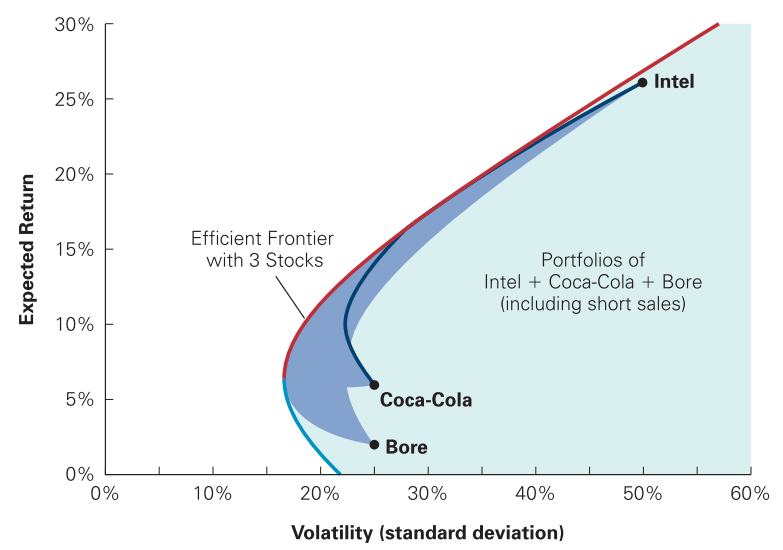

*Fonte: Berk. Corporate Finance (2016)*

#### Carteiras Eficientes

No exemplo anterior, o investidor escolheu a carteira composta com a ação da Coca Cola, uma vez que esta era dominante, dentre as opções que ele possui. Agora suponha que existe a carteira $A$, que assim como as ações apresentadas, possui uma volatilidade de 25%, mas a carteira $A$ representa a combinação de ativos com o maior retorno. Essa carteira será a carteira eficiente, uma vez que o investidor pode ficar numa melhor posição ao escolher $A$, invés das demais carteiras.

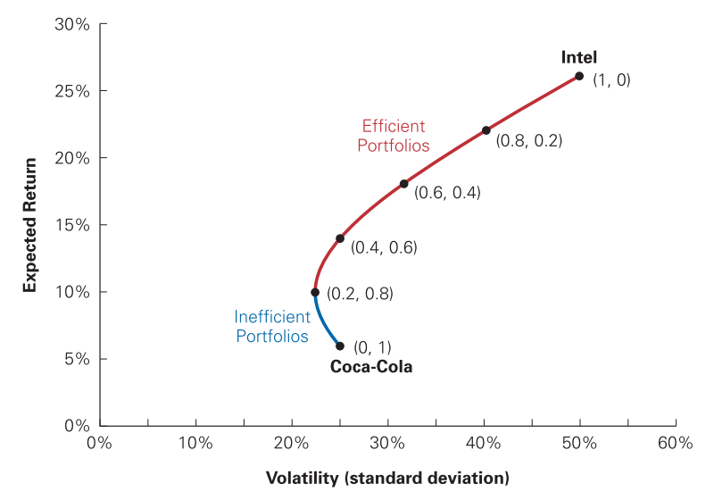

*Fonte: Berk. Corporate Finance (2016)*

Note que na combinação $(0,1)$, em que a carteira é composta apenas por ativos da Coca-Cola, o risco é o mesmo que no ponto $(0.4, 0.6)$, em que 40% da carteira é composta por ações da Intel e 60% por ações da Coca-Cola, essa carteira apresenta o mesmo risco, entretanto o retorno é maior e ela está posicionada na fronteira de eficiência, isso significa que um investidor racional que está disposto a aceitar 25% de volatilidade, irá optar pela combinação $(0.4, 0.6)$.

Uma carteira eficiente, portanto, pode ser definida como aquela que apresenta o maior retorno esperado dado um nível de risco. Ou, alternativamente, a carteira de menor risco dado um nível de retorno, isto é, a carteira de variância mínima. Essa é a carteira que um investidor racional irá escolher dentre as opções que foram apresentadas para ele.

Partindo da uma visão de carteira de variância mínima, o problema de selecionar uma carteira pode ser definido como um problema de otimização. Isto é, como encontrar a carteira de menor risco dado um retorno desejado. Matematicamente:

$$\begin{equation}
\begin{split}
\underset{w}{min} &\quad w'M w\\
s.a &\\
& wR = R_d \\
& w\textbf{1} = 1
\end{split}
\end{equation}$$

Sendo $w$ o vetor de pesos da carteira a ser encontrada, $M$ a matriz de covariância dos retornos, $R$ o vetor com dos retornos de cada ativo, $R_d$ o retorno desejado para a carteira ótima e $\textbf1$ um vetor de cuja todas as coordenadas são 1. O problema de otimização tem duas restrições: $wR=R_d$ e $w\textbf{1}=1$. A primeira restrição afirma que a carteira ótima deve ter o retorno igual ao retorno desejado, já segunda afirma que a soma das participações de cada ativo deve somar 1.

Resolver tal problema de minimização significa encontrar a participação de cada ativo na carteira, os pesos, tal que a carteira tenha o menor risco entre todas as carteiras com os mesmos ativos e retorno igual $R_d$.